# Replication of Why Do We Hate Hypocrites? Evidence for a Theory of False Signaling by Jillian Jordan, Roseanna Sommers, Paul Bloom & David Rand (2016, Psychological Science)

Luiza A. Santos (lsantos1@stanford.edu)

October 28, 2018

## Introduction

As a graduate student in Psychology, I am interested in exploring the processes underlying moral cognition. One particular area of interest is to examine how people perceive different types of moral transgressions. Related to this topic, Jordan and colleagues (2016) sought to explain why hypocrites (i.e., those who condemn transgressions they engage in) are more disliked than individuals who commit the same transgressions without condemning them. The authors hypothesized that hypocrites are disliked because their condemnation falsely signals their own moral goodness. Although all five studies reported in this paper support this prediction in different ways, Study 4 is the only one that explicitly focuses on the false-signaling element and is, therefore, critical to the article’s key claim. Thus Study 4’s results will be the target of this replication.

As the authors made all data and materials publicly available via the Open Science Framework, potential replication difficulties have been significantly decreased. However, due to financial constraints, it may not be feasible to reproduce the paper’s original sample size of 457 subjects, which will negatively impact the statistical power of our replication.

Link to repository: https://github.com/SantosLuiza/Replication-Project Link to original paper: https://github.com/SantosLuiza/Replication-Project/blob/master/original_paper/jordan2016.pdf

## Methods

### Planned Sample

In the original paper, Jordan and colleagues recruited 457 subjects online using Amazon Mturk. For this replication project, we will agree upon a viable sample size after conducting a power analysis. We will analyze responses from all subjects who have unique IP addresses and have evaluated all the vignettes.

### Materials

We will use the same materials employed by original authors. All the experimental materials for this study are available online and can be accessed here: https://osf.io/2r8ab/.

Each participant will be presented with four vignettes (in random order), about downloading music illegally, evading jury duty, ignoring phone calls from one’s mother, and wasting paper by printing documents single-sided.

In each vignette, a target character discusses an acquaintance’s moral transgression and then privately goes on to engage in the same transgression. In a three-condition, between-subjects design, we will manipulate whether, before engaging in the relevant moral transgression, the target (a) condemned the violation (traditional-hypocrite condition), (b) condemned the violation but explicitly negated any signaling value of the condemnation (honest-hypocrite condition), or (c) said nothing (control-transgressor condition).

After reading the vignettes, participants will be asked to evaluate the target.

### Procedure

We will follow the original paper’s procedure precisely. Below is a detailed description of the study design as outlined by original authors.

“Each vignette described a conversation between two characters: a target (whom subjects would later evaluate) and a friend (whom subjects would not evaluate). In all conditions, this conversation began with the target and the friend discussing a mutual acquaintance. In this discussion, the friend mentioned that the mutual acquaintance often engaged in a particular moral transgression.”

“In the traditional-hypocrite condition, the target responded to the friend by condemning the transgression. In the honest-hypocrite condition, the target responded to the friend by stating that he or she believed the behavior in question to be morally wrong but sometimes behaved that way anyway. Finally, in the control-transgressor condition, we did not include any information about a response from the target. Shortly after this conversation ended, in all conditions, the target went on to commit the relevant violation.

For example, here is the full text for a scenario about downloading music illegally. In this scenario, Becky is the target character, and Amanda is the friend. In all conditions, the vignette began as follows:

```
Becky and her friend Amanda are discussing a mutual acquaintance. Amanda mentions that the acquaintance often downloads music illegally from the Internet.
```

In the traditional-hypocrite condition, the scenario continued with

```
Becky says that she thinks it is morally wrong to download music illegally from the Internet. Shortly after their conversation, Becky goes online, and downloads music illegally.
```

In the honest-hypocrite condition, the passage instead continued with

```
Becky says that she thinks it is morally wrong to download music illegally from the Internet, but that she sometimes does it anyway. Shortly after their conversation, Becky goes online, and downloads music illegally.
```

Finally, in the control-transgressor condition, nothing was said about Becky’s opinion or behavior, and the passage simply ended with

```
Shortly after their conversation, Becky goes online, and downloads music illegally.
```

### Analysis Plan

To test the authors’ prediction, we will conduct a one-way ANOVA investigating the effect of condition on positive evaluations of the targets across the vignettes.

Following the original article criteria, we will exclude from the analysis participants who have identical IP addresses and those who do not complete the survey.

LINK TO PARADIGM: https://stanforduniversity.qualtrics.com/jfe/form/SV_5nJWFtwbmrNq3jL

## Results

### Data preparation

Data preparation

```r
###Import data and Load Relevant Libraries and Functions
library(tidyverse)
```

```r
library(ggplot2)
pre_data <- read_csv("pre_data.csv")
head(pre_data)
```

```
## # A tibble: 6 x 79
##   startDate    endDate     status   ipAddress   progress duration finished
##   <chr>        <chr>       <chr>    <chr>          <int>    <int> <lgl>
## 1 10/25/2018 ~ 10/25/2018~ Survey ~ <NA>             100       57 TRUE
## 2 10/28/2018 ~ 10/28/2018~ IP Addr~ 108.211.10~      100      138 TRUE
## 3 10/28/2018 ~ 10/28/2018~ Survey ~ <NA>             100       80 TRUE
## 4 10/28/2018 ~ 10/28/2018~ Survey ~ <NA>             100       47 TRUE
## 5 10/28/2018 ~ 10/28/2018~ Survey ~ <NA>             100       95 TRUE
## 6 10/28/2018 ~ 10/28/2018~ Survey ~ <NA>             100       52 TRUE
## # ... with 72 more variables: recordedDate <chr>, `_recordId` <chr>,
## #   recipientLastName <chr>, recipientFirstName <chr>,
## #   recipientEmail <chr>, externalDataReference <chr>,
## #   locationLatitude <dbl>, locationLongitude <dbl>,
## #   distributionChannel <chr>, userLanguage <chr>, Trustworthy <int>,
## #   Hypocritical <int>, Like <int>, Honest <int>, Good <int>,
## #   Trustworthy_1 <int>, Hypocritical_1 <int>, Like_1 <int>,
## #   Honest_1 <int>, Good_1 <int>, Trustworthy_2 <int>,
## #   Hypocritical_2 <int>, Like_2 <int>, Honest_2 <int>, Good_2 <int>,
## #   Trustworthy_3 <int>, Hypocritical_3 <int>, Like_3 <int>,
## #   Honest_3 <int>, Good_3 <int>, Trustworthy_4 <int>,
## #   Hypocritical_4 <int>, Like_4 <int>, Honest_4 <int>, Good_4 <int>,
## #   Trustworthy_5 <int>, Hypocritical_5 <int>, Like_5 <int>,
## #   Honest_5 <int>, Good_5 <int>, Trustworthy_6 <int>,
## #   Hypocritical_6 <int>, Like_6 <int>, Honest_6 <int>, Good_6 <int>,
## #   Trustworthy_7 <int>, Hypocritical_7 <int>, Like_7 <int>,
## #   Honest_7 <int>, Good_7 <int>, Trustworthy_8 <int>,
## #   Hypocritical_8 <int>, Like_8 <int>, Honest_8 <int>, Good_8 <int>,
## #   Trustworthy_9 <int>, Hypocritical_9 <int>, Like_9 <int>,
## #   Honest_9 <int>, Good_9 <int>, Trustworthy_10 <int>,
## #   Hypocritical_10 <int>, Like_10 <int>, Honest_10 <int>, Good_10 <int>,
## #   Trustworthy_11 <int>, Hypocritical_11 <int>, Like_11 <int>,
## #   Honest_11 <int>, Good_11 <int>, `Random ID` <int>, Condition <chr>
```

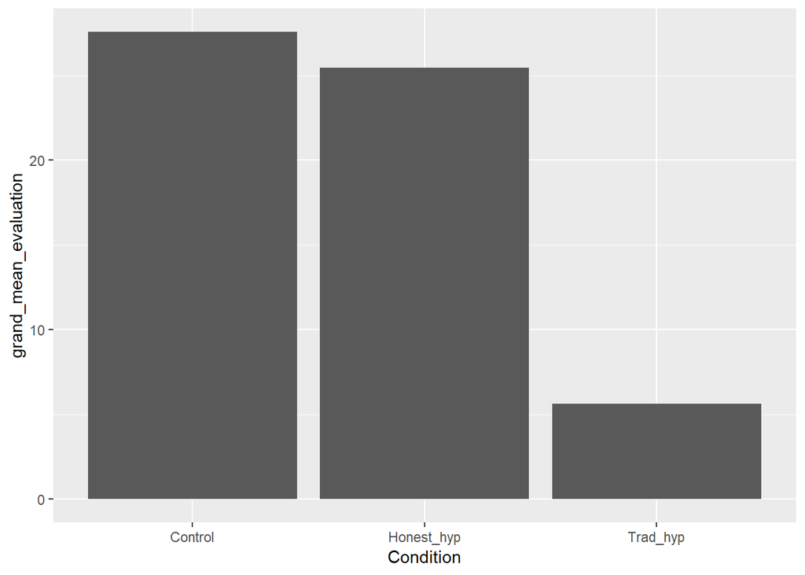

```r
###Prepare data for analysis
pre_data <- pre_data %>%
  gather(item_pos, evaluation_pos, starts_with("Trust"), starts_with("Good"), starts_with("Honest"),
         starts_with("Like")) %>%
  gather(item_neg, evaluation_neg, starts_with("Hypo"))

pre_data <- pre_data %>%
  select(`Random ID`, item_pos, item_neg, evaluation_pos, evaluation_neg, Condition)

###Analyzing differences in means

Sub_pos_means <- pre_data %>%
  group_by(`Random ID`, Condition) %>%
  summarise(sub_mean = mean(evaluation_pos, na.rm=TRUE))

Sub_pos_means <- Sub_pos_means[-2, ]

Grand_means <- Sub_pos_means %>%
  group_by(Condition) %>%
  summarise(grand_mean_evaluation = mean(sub_mean, na.rm=TRUE))

plot <- ggplot(Grand_means, aes(x = Condition, y = grand_mean_evaluation)) +
   geom_bar(stat="identity")

plot
```

```r
#### Data exclusion / filtering

#Delete subjects who have identical IP adresses or who have not completed the survey
```

### Confirmatory analysis

The analyses as specified in the analysis plan.

```r
###One way ANOVA
pos_aov <- aov(evaluation_pos ~ Condition, data = pre_data)
summary(pos_aov)
```

```
##              Df Sum Sq Mean Sq F value Pr(>F)
## Condition     2  90339   45169   701.6 <2e-16 ***
## Residuals   849  54656      64
## ---
## Signif. codes:  0 '***' 0.001 '**' 0.01 '*' 0.05 '.' 0.1 ' ' 1
## 2604 observations deleted due to missingness
```